# College_Basketball_Data_Analysis

Authors

Blessing Amoah

Alex Barnard

Fengyi Li

```r
# glimpse of the data
glimpse(data)
```

```
Rows: 1,447
Columns: 18
$ Season       <dbl> 2025, 2025, 2025, 2025, 2025, 2025, 2025, 2025, 2025, 202…
$ TeamName     <chr> "Abilene Christian", "Air Force", "Akron", "Alabama", "Al…
$ Tempo        <dbl> 70.0679, 64.6651, 72.4588, 76.2512, 71.8121, 69.0571, 68.…
$ RankTempo    <dbl> 72, 334, 15, 1, 20, 120, 161, 272, 357, 354, 64, 81, 54, …
$ AdjTempo     <dbl> 69.3532, 64.3683, 71.3708, 74.8553, 70.9783, 67.7458, 67.…
$ RankAdjTempo <dbl> 67, 324, 16, 1, 22, 142, 162, 315, 349, 351, 54, 112, 68,…
$ OE           <dbl> 95.6706, 95.3082, 115.7540, 118.7250, 94.8255, 103.9980, …
$ RankOE       <dbl> 346, 347, 22, 9, 352, 228, 169, 325, 215, 254, 27, 227, 1…
$ AdjOE        <dbl> 97.6324, 98.9012, 113.6890, 126.5110, 92.0141, 101.4100, …
$ RankAdjOE    <dbl> 328, 312, 66, 4, 361, 270, 235, 331, 252, 278, 12, 78, 73…
$ DE           <dbl> 100.7730, 113.1050, 104.5580, 106.1210, 109.9650, 104.201…
$ RankDE       <dbl> 60, 335, 145, 176, 277, 129, 218, 244, 160, 56, 88, 224, …
$ AdjDE        <dbl> 102.0970, 111.4670, 107.1090, 96.5798, 115.5150, 110.6470…
$ RankAdjDE    <dbl> 86, 272, 183, 32, 334, 256, 285, 281, 205, 79, 33, 75, 20…
$ AdjEM        <dbl> -4.465030, -12.565500, 6.579070, 29.931700, -23.500700, -…
$ RankAdjEM    <dbl> 219, 310, 99, 6, 360, 273, 270, 325, 237, 170, 14, 70, 40…
$ seed         <dbl> NA, NA, 13, 2, NA, 16, NA, NA, 16, NA, 4, NA, 10, NA, NA,…
$ final_four   <dbl> NA, NA, NA, NA, NA, NA, NA, NA, NA, NA, NA, NA, NA, NA, N…
```

## Data Source

This data includes metrics such as:

- Tempo (pace of play)
- Offensive/Defensive Efficiency (OE/DE)
- Adjusted metrics (AdjOE, AdjDE)
- Team seeds which indicates their tournament ranking.

## Research question

Our goal is to answer the question:

What is the probability that a team reaches the Final Four, based on its adjusted offensive efficiency (AdjOE), adjusted defensive efficiency (AdjDE), and adjusted tempo (AdjTempo)?

We aim to identify which team characteristics, among these core performance metrics, most strongly predict tournament success.

## Variables of Interest

- Response variable: Final_four

This is a binary variable indicating whether a team made it to the Final Four (TRUE) or not (FALSE)

- Key predictor: AdjOE thus Adjusted Offensive Efficiency
- Other predictors may include AdjDE, AdjTempo.

```r
# Convert Final Four appearance to binary (TRUE if team reached Final Four, FALSE otherwise)

data <- data %>%
  mutate(final_four = if_else(final_four == 1, TRUE, FALSE))

# Check the class balance
table(data$final_four)
```

```
TRUE
  16
```

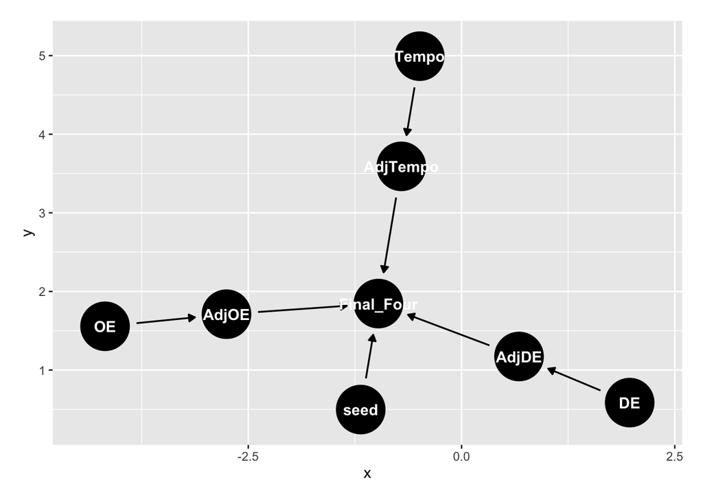

```r
#| echo: false

offensive_defensive_metrics <- dagitty("dag{
  AdjOE -> Final_Four;
  AdjDE -> Final_Four;
  AdjTempo -> Final_Four;
  seed -> Final_Four;
  Tempo -> AdjTempo;
  OE -> AdjOE;
  DE -> AdjDE;
}")

ggdag(offensive_defensive_metrics) +
  theme(plot.margin = margin(15, 15, 15, 15))
```

Interpretation

The causal diagram illustrates the assumed relationships between the variables in our analysis. The primary goal is to model the probability of a team reaching the Final Four (Final_Four) based on several performance metrics.

- Predictors Included: We will include AdjOE, AdjDE, and AdjTempo as direct predictors of Final_Four. These variables represent adjusted offensive efficiency, adjusted defensive efficiency, and adjusted tempo, respectively.
- Predictors Excluded: We will not directly include OE, DE, and Tempo in the model. This is because these variables are assumed to determine AdjOE, AdjDE, and AdjTempo. Including both the original and adjusted metrics would introduce multicollinearity, as the adjusted metrics are, in part, derived from the original ones. Multicollinearity makes it difficult to isolate the independent effect of each predictor.

Model Description

$$\text{final\_four}_i \sim \text{Binomial}(1, p_i)$$

$$\text{logit}(p_i) = \beta_1 \cdot \text{AdjOE}_i + \beta_2 \cdot \text{AdjDE}_i + \beta_3 \cdot \text{AdjTempo}_i + \alpha_{\text{seed}[i]}$$

Priors for only final four teams

```r
clean_data <- data %>%
  drop_na(final_four, seed, AdjOE, AdjDE, AdjTempo) %>%
  mutate(seed = as.integer(as.factor(seed)))
nrow(clean_data)
```

```
[1] 16
```

```r
dat_final_four_only <- list(
  n = nrow(clean_data),
  final_four = as.integer(clean_data$final_four),
  AdjOE = as.numeric(scale(clean_data$AdjOE)),
  AdjDE = as.numeric(scale(clean_data$AdjDE)),
  AdjTempo = as.numeric(scale(clean_data$AdjTempo)),
  S = length(unique(clean_data$seed)),
  seed = clean_data$seed
)
```

priors for all teams included in the NCAA tournament

```r
dat_all_teams <- data %>% mutate(final_four = ifelse(is.na(final_four), 0, final_four))
```

```r
# Convert Final Four appearance to binary (TRUE if team reached Final Four, FALSE otherwise)

dat_all_teams <- dat_all_teams %>%
  mutate(final_four = ifelse(final_four >= 1, TRUE, FALSE))


# check the class balance
table(dat_all_teams$final_four)
```

```
FALSE  TRUE
 1431    16
```

```r
dat_all_teams <- dat_all_teams %>%
  drop_na(seed)
nrow(dat_all_teams)
```

```
[1] 272
```

```r
table(dat_all_teams$final_four)
```

```
FALSE  TRUE
  256    16
```

```r
dat_all_teams <- list(
  n = nrow(dat_all_teams),
  final_four = as.integer(dat_all_teams$final_four),
  AdjOE = scale(dat_all_teams$AdjOE),
  AdjDE = scale(dat_all_teams$AdjDE),
  AdjEM = scale(dat_all_teams$AdjEM),
  AdjTempo = scale(dat_all_teams$AdjTempo),
  seed = dat_all_teams$seed


#  N = nrow(clean_data),
#  N_seeds = max(clean_data$seed, na.rm = TRUE)
)
```

## Prior Rationale

Choice of Distribution: - We use normal distributions for the priors of β1 (AdjOE), β2 (AdjDE), and β3 (AdjTempo) because the coefficients in a logistic regression represent the change in the log-odds of the outcome for a one-unit change in the predictor. Normal distributions are suitable for these coefficients as they allow for both positive and negative effects, and they are symmetric around a central value, representing our best guess.

Prior for β3 (AdjTempo): - Prior Distribution: β3 ~ Normal(0, 0.2) - Prior Mean (0): We set the prior mean to 0. This expresses our initial belief that adjusted tempo may have little to no effect on the probability of reaching the Final Four. - Prior Standard Deviation (0.2): Again, this reflects moderate uncertainty, allowing for tempo to have either a small positive or negative effect.

References

- Gelman, Andrew, et al. Bayesian Data Analysis. 3rd ed., CRC Press, 2013.
- McElreath, Richard. Statistical Rethinking: A Bayesian Course with Examples in R and Stan. 2nd ed., CRC Press, 2020.

Prior Predictive Distribution of final four teams only

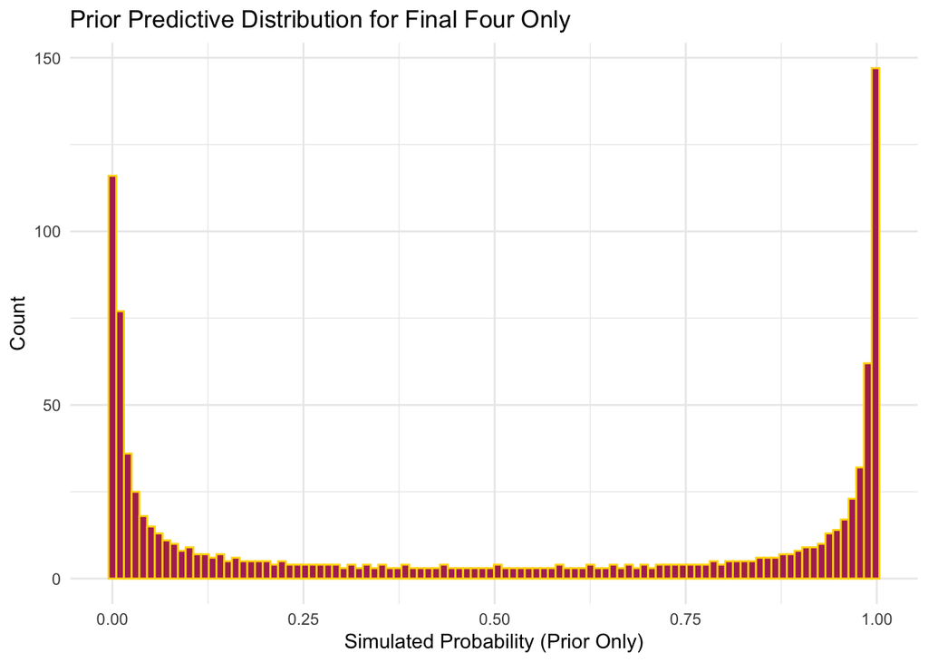

```r
# Simulate Prior Predictive Distribution

# Number of simulations
n_sim <- 1000
target_probability = (4/68)

# Sample from priors
b1_prior <- rnorm(n_sim, logit(0.10), 0.2)
b2_prior <- rnorm(n_sim, logit(0.15), 0.2)
b3_prior <- rnorm(n_sim, 0, 0.2)
b4_prior <- rnorm(n_sim, 0, 1)

# Create a sequence of predictor values (scaled)
AdjOE_seq <- seq(-2, 2, length.out = n_sim)
AdjDE_seq <- seq(-2, 2, length.out = n_sim)
AdjTempo_seq <- seq(-2, 2, length.out = n_sim)

# Create empty matrices to store predictions
p_prior <- matrix(NA, nrow = n_sim, ncol = length(AdjOE_seq))

logit_target <- target_probability

# Simulate probabilities
for (i in 1:n_sim) {
  for (j in 1:length(AdjOE_seq)) {
    # Using the same values for all predictors for simplicity
    log_odds <- b4_prior[i] +  b1_prior[i] * AdjOE_seq[j] + b2_prior[i] * AdjDE_seq[j] + b3_prior[i] * AdjTempo_seq[j]
    p_prior[i, j] <- inv_logit(log_odds)
  }
}

# Average the probabilities across simulations
mean_p_prior <- colMeans(p_prior)

final_four_sim <- rbinom(n_sim, size = 1, prob = mean_p_prior)

# Plot histogram of prior predictive probabilities
prior_sim_df <- data.frame(probability = mean_p_prior)
ggplot(prior_sim_df, aes(x = probability)) +
  geom_histogram(bins = 100, fill = "maroon", color = "gold") +
  labs(title = "Prior Predictive Distribution for Final Four Only",
       x = "Simulated Probability (Prior Only)",
       y = "Count") +
  theme_minimal()
```

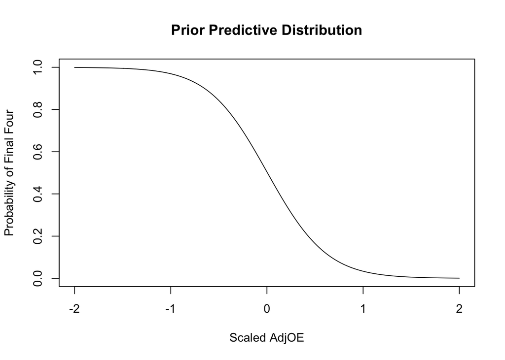

```r
# Plot the prior predictive distribution
plot(AdjOE_seq, mean_p_prior, type = "l",
     xlab = "Scaled AdjOE", ylab = "Probability of Final Four",
     main = "Prior Predictive Distribution")
```

PPD of all teams included in the NCAA tournament

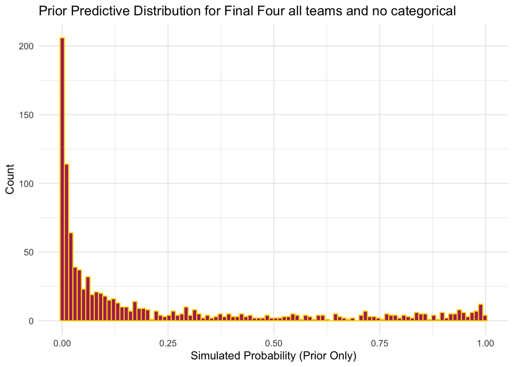

```r
set.seed = 1
# Set number of simulations
n_sim <- 1000 #
target_probability = (4/68) #only 4/68 teams can make a final four

# Simulate prior values for coefficients
b1 <- rnorm(n_sim, logit(.1), .2) # 1 sd in AjdOE gives a 10% increase of making a final four
b2 <- rnorm(n_sim, logit(.15), .2)
b4 <- rnorm(n_sim, 0, .2)
b5 <- rnorm(n_sim, -logit(.2), .2)

# Simulate group-level effects

# Simulate standardized predictor values
AdjOE <- rnorm(n_sim)
AdjDE <- rnorm(n_sim)
AdjTempo <- rnorm(n_sim)
b_seed <- rnorm(n_sim)

# Linear predictor
logit_p <- b1 * AdjOE + b2 * AdjDE + b4 * AdjTempo + b5 * b_seed

logit_target <- logit(target_probability)

logit_p <- logit_p - (mean(logit_p) - logit_target) #scale down logit to more accurately reflect only 200 teams making it

# Transform to probability
p <- 1 / (1 + exp(-logit_p))


# Simulate binary final_four outcome
final_four_sim <- rbinom(n_sim, size = 1, prob = p)

# Make dataframe for plotting
prior_sim_df <- tibble(
  probability = p,
  outcome = final_four_sim
)

# Plot histogram of prior predictive probabilities
ggplot(prior_sim_df, aes(x = probability)) +
  geom_histogram(bins = 100, fill = "maroon", color = "gold") +
  labs(title = "Prior Predictive Distribution for Final Four all teams and no categorical",
       x = "Simulated Probability (Prior Only)",
       y = "Count") +
  theme_minimal()
```

Interpretation

- The plot shows the average predicted probability of reaching the Final Four as a function of the scaled AdjOE.

- we incorporated the prior distribution for the seed-level intercept (alpha_seed ~ Normal(0, 1)) into the log-odds computation via b4_prior. This reflects uncertainty about baseline differences in teams’ likelihood to reach the Final Four based on seed.

all teams post

```r
no_categorical_stan_model <- '
data{
    int<lower=1> n;
    array[n] int final_four; //resp var
    array[n] real AdjOE;
    array[n] real AdjDE;
    array[n] real AdjTempo;
    array[n] int seed;
}
parameters{
    real b1;
    real b2;
    real b3;
    real b4;
}
model{
    vector[n] p;
    b1 ~ normal(logit(.1), .2); //AdjOE
    b2 ~ normal(logit(.15), .2); //AdjDE
    b3 ~ normal(0, .2); //tempo
    b4 ~ normal(-logit(.2), .2); //seed
    for ( i in 1:n ) {
        p[i] = inv_logit(b1 * AdjOE[i] + b2 * AdjDE[i] + b3 * AdjTempo[i] + b4 * seed[i]);
    }
    final_four ~ binomial( 1 , p ); // the 1 is for 1 "trial" per row of data
}
generated quantities{
    vector[n] p;
    vector[n] log_lik;
    for ( i in 1:n ) {
        p[i] = inv_logit(b1 + b2 + b3 + b4);
        log_lik[i] = binomial_lpmf(final_four[i] | 1, p[i]);
    }
}
'
```

```r
print(fit_no_cat, pars = c("b1", "b2", "b3", "b4"), probs = c(0.055, 0.945))
```

```
Inference for Stan model: anon_model.
4 chains, each with iter=2000; warmup=1000; thin=1;
post-warmup draws per chain=1000, total post-warmup draws=4000.

    mean se_mean   sd  5.5% 94.5% n_eff Rhat
b1 -1.50       0 0.17 -1.77 -1.23  3813    1
b2 -0.92       0 0.16 -1.18 -0.67  3136    1
b3  0.05       0 0.15 -0.19  0.28  3815    1
b4 -0.45       0 0.05 -0.53 -0.37  3477    1

Samples were drawn using NUTS(diag_e) at Fri May  2 14:37:40 2025.
For each parameter, n_eff is a crude measure of effective sample size,
and Rhat is the potential scale reduction factor on split chains (at
convergence, Rhat=1).
```

```
ci_level: 0.8 (80% intervals)
```

```
outer_level: 0.95 (95% intervals)
```

[figure not shown]

```r
traceplot(fit_no_cat, pars = c("b1", "b2", "b3", "b4"))
```

```r
print(fit_no_cat)
```

[output not shown]

[output cut: 1054 more lines]

```
log_lik[264]    1
log_lik[265]    1
log_lik[266]    1
log_lik[267]    1
log_lik[268]    1
log_lik[269]    1
log_lik[270]    1
log_lik[271]    1
log_lik[272]    1
lp__            1

Samples were drawn using NUTS(diag_e) at Fri May  2 14:37:40 2025.
For each parameter, n_eff is a crude measure of effective sample size,
and Rhat is the potential scale reduction factor on split chains (at
convergence, Rhat=1).
```

final four teams only posterior

```r
final_four_only_stan_model <- '
data {
  int<lower=1> n;
  array[n] int final_four;
  array[n] real AdjOE;
  array[n] real AdjDE;
  array[n] real AdjTempo;
  int<lower=1> S;
  array[n] int seed;
}

parameters {
  real b1;
  real b2;
  real b3;
  vector[S] alpha_seed;
}

model {
  vector[n] p;

  b1 ~ normal(logit(0.10), 0.2);
  b2 ~ normal(logit(0.15), 0.2);
  b3 ~ normal(0, 0.2);
  alpha_seed ~ normal(0, 1);

  for (i in 1:n) {
    p[i] = inv_logit(alpha_seed[seed[i]] +
                     b1 * AdjOE[i] +
                     b2 * AdjDE[i] +
                     b3 * AdjTempo[i]);
  }

  final_four ~ binomial(1, p);
}

generated quantities {
  vector[n] p;
  vector[n] log_lik;
  for (i in 1:n) {
    p[i] = inv_logit(alpha_seed[seed[i]] +
                     b1 * AdjOE[i] +
                     b2 * AdjDE[i] +
                     b3 * AdjTempo[i]);
    log_lik[i] = binomial_lpmf(final_four[i] | 1, p[i]);
  }
}
'
```

```r
print(fit_final_four_only, pars = c("b1", "b2", "b3"), probs = c(0.055, 0.945))
```

```
Inference for Stan model: anon_model.
4 chains, each with iter=2000; warmup=1000; thin=1;
post-warmup draws per chain=1000, total post-warmup draws=4000.

    mean se_mean   sd  5.5% 94.5% n_eff Rhat
b1 -2.13       0 0.20 -2.45 -1.80  8953    1
b2 -1.62       0 0.19 -1.93 -1.32  8069    1
b3  0.08       0 0.19 -0.22  0.39  7953    1

Samples were drawn using NUTS(diag_e) at Fri May  2 14:38:04 2025.
For each parameter, n_eff is a crude measure of effective sample size,
and Rhat is the potential scale reduction factor on split chains (at
convergence, Rhat=1).
```

```
ci_level: 0.8 (80% intervals)
```

```
outer_level: 0.95 (95% intervals)
```

[figure not shown]

```r
traceplot(fit_final_four_only, pars = c("b1", "b2", "b3"))
```

```r
print(fit_final_four_only)
```

```
Inference for Stan model: anon_model.
4 chains, each with iter=2000; warmup=1000; thin=1;
post-warmup draws per chain=1000, total post-warmup draws=4000.

                mean se_mean   sd   2.5%    25%    50%    75%  97.5% n_eff Rhat
b1             -2.13    0.00 0.20  -2.52  -2.26  -2.13  -1.99  -1.71  8953    1
b2             -1.62    0.00 0.19  -2.01  -1.75  -1.62  -1.50  -1.24  8069    1
b3              0.08    0.00 0.19  -0.29  -0.05   0.08   0.20   0.47  7953    1
alpha_seed[1]   2.11    0.01 0.70   0.78   1.63   2.10   2.58   3.50  9362    1
alpha_seed[2]   0.48    0.01 0.88  -1.17  -0.12   0.47   1.09   2.20  8563    1
alpha_seed[3]   1.12    0.01 0.91  -0.63   0.53   1.12   1.73   2.94  7822    1
alpha_seed[4]   0.75    0.01 0.91  -1.04   0.12   0.77   1.41   2.52  8683    1
alpha_seed[5]   0.13    0.01 0.97  -1.77  -0.51   0.12   0.76   2.07  8391    1
alpha_seed[6]   0.11    0.01 0.96  -1.76  -0.53   0.12   0.75   2.02  7446    1
alpha_seed[7]   0.38    0.01 0.91  -1.36  -0.25   0.37   1.01   2.18  8416    1
p[1]            0.50    0.00 0.16   0.20   0.38   0.50   0.61   0.81 10171    1
p[2]            0.79    0.00 0.12   0.51   0.72   0.81   0.88   0.95  8522    1
p[3]            0.58    0.00 0.16   0.26   0.46   0.58   0.70   0.85 10788    1
p[4]            0.97    0.00 0.03   0.90   0.96   0.98   0.99   1.00  4415    1
p[5]            0.05    0.00 0.06   0.00   0.02   0.03   0.06   0.20  3763    1
p[6]            0.54    0.00 0.16   0.23   0.42   0.55   0.66   0.84  9755    1
p[7]            0.61    0.00 0.19   0.21   0.46   0.63   0.76   0.92  7908    1
p[8]            0.57    0.00 0.15   0.28   0.46   0.58   0.69   0.85 10200    1
p[9]            0.86    0.00 0.11   0.58   0.81   0.89   0.93   0.98  5219    1
p[10]           0.87    0.00 0.11   0.59   0.83   0.91   0.95   0.99  4691    1
p[11]           0.26    0.00 0.16   0.04   0.13   0.23   0.36   0.64  7061    1
p[12]           0.99    0.00 0.01   0.97   0.99   1.00   1.00   1.00  4279    1
p[13]           0.68    0.00 0.17   0.32   0.57   0.71   0.82   0.93  7943    1
p[14]           0.95    0.00 0.03   0.86   0.94   0.96   0.98   0.99  6525    1
p[15]           0.89    0.00 0.10   0.61   0.85   0.92   0.96   0.99  4719    1
p[16]           0.84    0.00 0.12   0.55   0.78   0.87   0.93   0.98  6367    1
log_lik[1]     -0.75    0.00 0.36  -1.59  -0.97  -0.70  -0.49  -0.22  9956    1
log_lik[2]     -0.25    0.00 0.16  -0.68  -0.33  -0.21  -0.13  -0.05  7234    1
log_lik[3]     -0.60    0.00 0.31  -1.35  -0.78  -0.54  -0.36  -0.16  9474    1
log_lik[4]     -0.03    0.00 0.03  -0.10  -0.04  -0.02  -0.01   0.00  4222    1
log_lik[5]     -3.49    0.01 1.02  -5.59  -4.14  -3.47  -2.79  -1.58  7619    1
log_lik[6]     -0.66    0.00 0.34  -1.46  -0.86  -0.60  -0.41  -0.18  8641    1
log_lik[7]     -0.57    0.01 0.39  -1.57  -0.77  -0.47  -0.27  -0.09  5824    1
log_lik[8]     -0.60    0.00 0.30  -1.28  -0.77  -0.55  -0.37  -0.16  9154    1
log_lik[9]     -0.16    0.00 0.15  -0.55  -0.21  -0.12  -0.07  -0.02  4413    1
log_lik[10]    -0.14    0.00 0.14  -0.53  -0.18  -0.10  -0.05  -0.01  4294    1
log_lik[11]    -1.58    0.01 0.73  -3.14  -2.06  -1.49  -1.03  -0.44  7849    1
log_lik[12]    -0.01    0.00 0.01  -0.03  -0.01   0.00   0.00   0.00  4231    1
log_lik[13]    -0.42    0.00 0.29  -1.15  -0.57  -0.35  -0.20  -0.07  6292    1
log_lik[14]    -0.05    0.00 0.04  -0.15  -0.06  -0.04  -0.02  -0.01  6223    1
log_lik[15]    -0.13    0.00 0.13  -0.49  -0.16  -0.08  -0.04  -0.01  4153    1
log_lik[16]    -0.18    0.00 0.16  -0.60  -0.24  -0.13  -0.07  -0.02  5452    1
lp__          -17.51    0.05 2.26 -22.77 -18.81 -17.16 -15.85 -14.13  1840    1

Samples were drawn using NUTS(diag_e) at Fri May  2 14:38:04 2025.
For each parameter, n_eff is a crude measure of effective sample size,
and Rhat is the potential scale reduction factor on split chains (at
convergence, Rhat=1).
```

```r
# Extract posterior samples
final_four_only_posterior_samples <- as.data.frame(fit_final_four_only)

final_four_only_posterior_summary <- final_four_only_posterior_samples %>%
  summarize(
    mean_b1 = mean(b1),
    median_b1 = median(b1),
    ci_lower_b1 = quantile(b1, 0.025),
    ci_upper_b1 = quantile(b1, 0.975),
    mean_b2 = mean(b2),
    median_b2 = median(b2),
    ci_lower_b2 = quantile(b2, 0.025),
    ci_upper_b2 = quantile(b2, 0.975),
    mean_b3 = mean(b3),
    median_b3 = median(b3),
    ci_lower_b3 = quantile(b3, 0.025),
    ci_upper_b3 = quantile(b3, 0.975)
  )

print(final_four_only_posterior_summary)
```

```
    mean_b1 median_b1 ci_lower_b1 ci_upper_b1   mean_b2 median_b2 ci_lower_b2
1 -2.127094 -2.130245   -2.515361   -1.714827 -1.624122 -1.624089   -2.009799
  ci_upper_b2    mean_b3  median_b3 ci_lower_b3 ci_upper_b3
1   -1.243029 0.08062199 0.07836428  -0.2920455   0.4707708
```

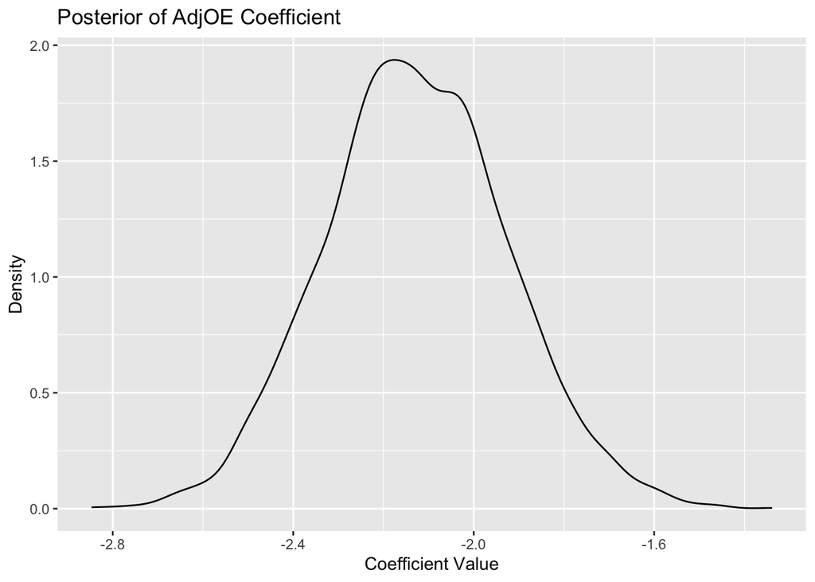

```r
final_four_only_plot_posterior <- function(param_name, title) {
  ggplot(final_four_only_posterior_samples, aes(x = .data[[param_name]])) +
    geom_density() +
    ggtitle(title) +
    xlab("Coefficient Value") +
    ylab("Density")
}

final_four_only_plot_posterior("b1", "Posterior of AdjOE Coefficient")
```

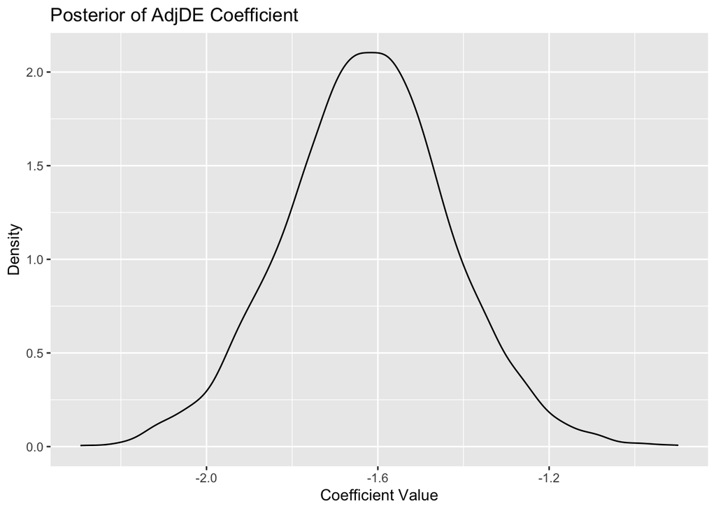

```r
final_four_only_plot_posterior("b2", "Posterior of AdjDE Coefficient")
```

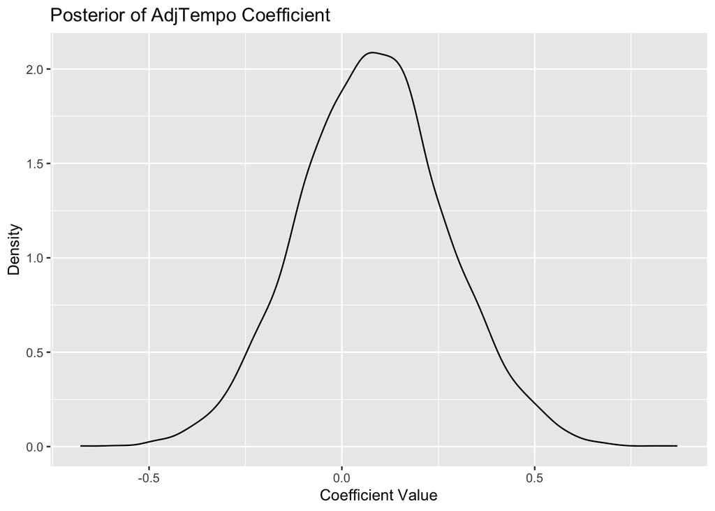

```r
final_four_only_plot_posterior("b3", "Posterior of AdjTempo Coefficient")
```

Interpretation

- The final_four_only_posterior_summary shows the mean, median, and 95% credible intervals for each coefficient.
- The density plots visualize the shape of the posterior distributions.

Model Comparison

```r
reduced_model_code <- '
data {
  int<lower=1> n;
  array[n] int final_four;
  array[n] real AdjOE;
}

parameters {
  real b1;
}

model {
  vector[n] p;
  b1 ~ normal(logit(0.10), 0.2);

  for (i in 1:n) {
    p[i] = inv_logit(b1 * AdjOE[i]);
  }

  final_four ~ binomial(1, p);
}

generated quantities {
  vector[n] p;
  vector[n] log_lik;
  for (i in 1:n) {
    p[i] = inv_logit(b1 * AdjOE[i]);
    log_lik[i] = binomial_lpmf(final_four[i] | 1, p[i]);
  }
}
'
```

```r
no_categorical_model_code <- '
data {
  int<lower=1> n;                    // number of observations
  array[n] int final_four;           // binary response: made Final Four
  array[n] real AdjOE;               // adjusted offensive efficiency
  array[n] real AdjDE;               // adjusted defensive efficiency
  array[n] real AdjTempo;            // adjusted tempo
  array[n] int seed;                 // seed as a continuous predictor
}

parameters {
  real b1;                           // coefficient for AdjOE
  real b2;                           // coefficient for AdjDE
  real b3;                           // coefficient for AdjTempo
  real b4;                           // coefficient for seed
}

model {
  vector[n] p;

  // Priors
  b1 ~ normal(logit(0.10), 0.2);     // AdjOE
  b2 ~ normal(logit(0.15), 0.2);     // AdjDE
  b3 ~ normal(0, 0.2);               // AdjTempo
  b4 ~ normal(-logit(0.20), 0.2);    // Seed effect

  // Likelihood
  for (i in 1:n) {
    p[i] = inv_logit(b1 * AdjOE[i] + b2 * AdjDE[i] + b3 * AdjTempo[i] + b4 * seed[i]);
  }

  final_four ~ binomial(1, p);
}

generated quantities {
  vector[n] p;
  vector[n] log_lik;

  for (i in 1:n) {
    p[i] = inv_logit(b1 * AdjOE[i] + b2 * AdjDE[i] + b3 * AdjTempo[i] + b4 * seed[i]);
    log_lik[i] = binomial_lpmf(final_four[i] | 1, p[i]);
  }
}
'
```

```r
# Extract log-likelihood matrices
log_lik_full <- rstan::extract(fit_final_four_only, pars = "log_lik")$log_lik
log_lik_reduced <- rstan::extract(fit_reduced, pars = "log_lik")$log_lik
log_lik_no_cat <- rstan::extract(fit_no_cat, pars = "log_lik")$log_lik

compute_waic <- function(log_lik_matrix) {
  lppd <- sum(log(colMeans(exp(log_lik_matrix))))
  p_waic <- sum(apply(log_lik_matrix, 2, var))
  waic <- -2 * (lppd - p_waic)
  return(list(WAIC = waic, lppd = lppd, p_waic = p_waic))
}

waic_full <- compute_waic(log_lik_full)
waic_reduced <- compute_waic(log_lik_reduced)
waic_no_cat <- compute_waic(log_lik_reduced)

print(paste("WAIC Full Model:", round(waic_full$WAIC, 2)))
```

```
[1] "WAIC Full Model: 21.82"
```

```r
print(paste("WAIC Reduced Model:", round(waic_reduced$WAIC, 2)))
```

```
[1] "WAIC Reduced Model: 34.81"
```

```r
print(paste("WAIC no categorical:", round(waic_no_cat$WAIC, 2)))
```

```
[1] "WAIC no categorical: 34.81"
```

Interpretation

```r
# MCMC diagnostics
rhats <- rhat(fit_final_four_only)
print(summary(rhats))
```

```
   Min. 1st Qu.  Median    Mean 3rd Qu.    Max.
 0.9992  0.9995  0.9998  0.9998  1.0000  1.0007
```

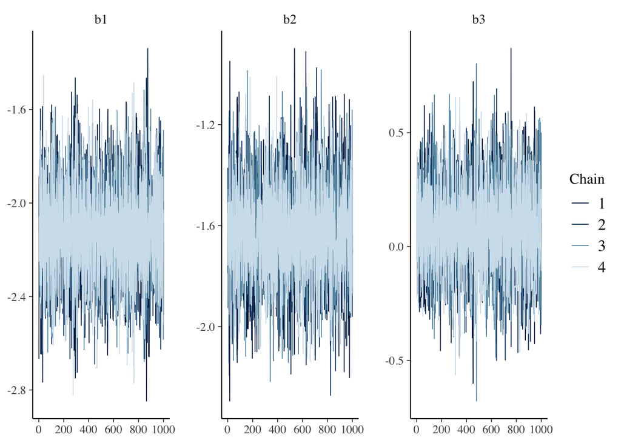

```r
mcmc_trace(fit_final_four_only, pars = c("b1", "b2", "b3"))
```

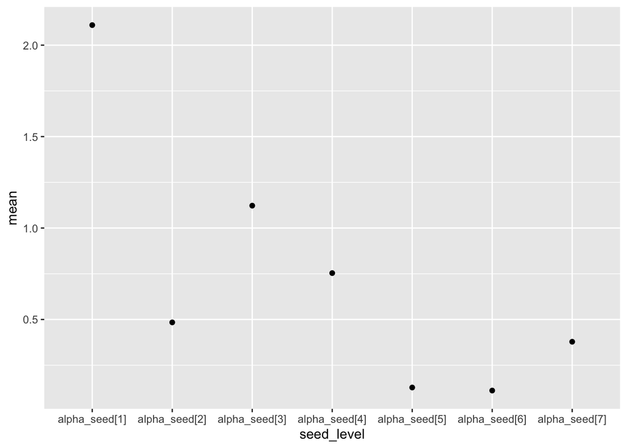

```r
final_four_only_posterior_samples %>%
  select(starts_with("alpha_seed")) %>%
  pivot_longer(cols = everything(), names_to = "seed_level", values_to = "value") %>%
  group_by(seed_level) %>%
  summarize(mean = mean(value)) %>%
  gf_point(mean ~ seed_level)
```

Discussion Questions & Answers

What is the probability that a team reaches the Final Four, based on its adjusted offensive efficiency (AdjOE), adjusted defensive efficiency (AdjDE), and adjusted tempo (AdjTempo), and seed line (Seed)?

Adjusted Defensive Efficiency (AdjDE)

- negative correlation with the likelihood of making it to the Final Four, as anticipated.
- higher defensive efficiency, or lower AdjDE values, increases the likelihood of making it to the Final Four; the posterior mean of b2 is negative.
- shows that longer tournament runs are predicted by stronger defenses (lower AdjDE).

Adjusted Tempo (AdjTempo)

- the posterior distribution of b3 has a wide degree of uncertainty and centered around 0.
- implies that the likelihood of making it to the Final Four is not much impacted by tempo.

Seed (via hierarchical model)

- Baseline odds of making it to the Final Four are often higher for teams with stronger seeds (lower seed numbers).
- Partial pooling across seed categories (alpha_seed) is possible with the hierarchical model, demonstrating performance variability that cannot be fully explained by metrics such as AdjOE/AdjDE alone.

Model Comparison

Overall Conclusion

- The best indicators of a team’s chances of making it to the Final Four are its offensive and defensive performance.
- Tempo doesn’t have a big impact on results.
- Model accuracy is increased through seeding, which reflects tournament committees’ inherent strength evaluations.